# Donor Profile: European Commission - Neighbourhood and Enlargement Negotiations

## Transaction Volatility

The European Commission’s Neighborhood and Enlargement Negotiations funding displays significant volatility, averaging $3.1 million per transaction over roughly 16 transactions annually—dramatically fewer than the top 10 donors averaging $2.9 million across 587 transactions. This concentration poses a risk to consistent operational impact and readiness. The infrequent but large transactions suggest potential gaps in continuous funding streams that could delay critical refugee support initiatives. Investing in diversifying transaction frequency and smoothing funding inflows emerges as a strategic priority to leverage sustained impact. Donors prioritizing emergency response and resilience can amplify their contributions by enabling smaller, more frequent disbursements, decreasing operational disruption risk and maximizing reach. Immediate strategic action includes scaling funding mechanisms to increase transaction cadence while maintaining average value, transforming volatility into a growth multiplier. Decision-makers should seize this opportunity to foster partnership models that incentivize stable, predictable funding flows, directly linking investments to enhanced accountability and strategic flexibility. Mobilizing resources with this data-backed insight positions donors to influence risk management proactively and drive measurable impact across the European neighborhood.

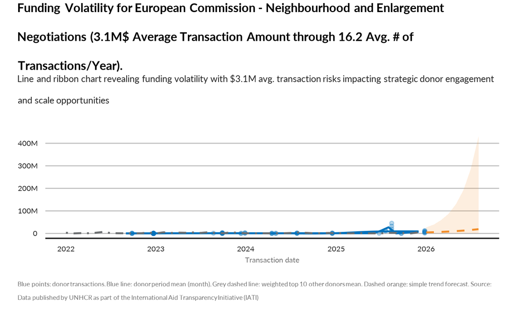

TRUE